# Your Digest for Monday, Jan 01, 2024 11:59 PM

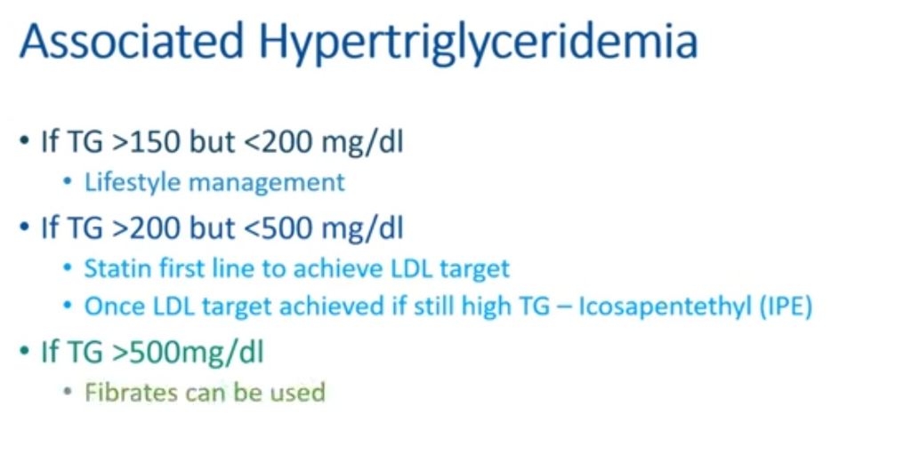

> Patient develops fever with #lymphadeonpathy after a few weeks of returning from a trip where he may have drunk unpasturerized milk.

# Grading or cardiac murmurs

| Grade | Characteristics |
| --- | --- |
| 1 | Consultant has difficultly hearing |
| 2 | Consultant can hear it clearly |
| 3 | <- **Loud but no thril** |
| 4 | Slight thrill |
| 5 | Thrill easily palpable |
| 6 | Heart with stethoscope off the chest. |

See also: [[Basic Sciencies - MCQ reading#Dynamic auscultation]]

## Mitral regurgitation

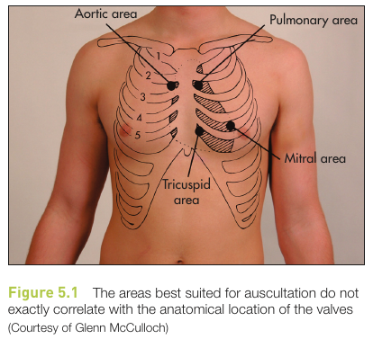

**Basic Science**

- The apex beat is caused by ventricular systole.
- Normally located in the 5th ICS, internal to the mid clavicular line.
- Double apex beat is a feature of decreased ventricular compliance.
  - (hypertension, aortic stenosis, hypertrophic cardiomyopathy)
- Pitch
  - high velocity of flow -> **High pitch murmurs** (MR)
  - low velocity flow -> **low pitch murmurs** (MS)

**Aetiologies**:

- MR can be *caused* by LV dilation (which results from LV failure)
1. Mitral valve prolapse
   1. The **most common valvular abnormality** (seen in 1-2% of people)
   2. Most are asymptomatic. Usually benign course.
   3. but complications:
      1. MR, infective endocarditis, *sudden cardiac death*.
   4. Associated with low body weight, thinly built people.
   5. Pathogenesis may have a inheritec component.
   6. *Etiology*: most often an isolated finding but associated with connective tissue disorders (Marfans, osteogenesis imperfecta) etc.
2. Degenerative (age associated)
3. Rheumatic heart disease
4. Papillary muscle dysfunction (Ischemic or other)
5. Cardiomyopathy (HOCM, dilated or restrictive)
6. Connective tissue disease (Marfan's, [[2022 November SBR#Rheumatoid arthritis|rheumatoid arthritis]], ankylosing spondylitis)
7. Congenital  
   Signs:  
   **Signs of increased severity**
- small volume pulse
- Enlarged LV
- Loud S3
- Soft S1
- Early A2 - rapid ventricular decompression
- Signs of PHT and left ventricular failure.

Murmur characteristics:

- Location: 5th ICS, mid clavicular line or the **location of the apex beat**, radiates to the **axilla**
- Duration: Pansystolic
- High pitched (use diaphragm)
- Soft S1
- Can have associated S3.
- S4 also may be heard.
- **Loudness correlates with severity**.
- **Palpation**:
  - Displaced apex beat
  - Parasternal heave (dilated LA displaces the RV)

**Associations**:

- regurgitation -> atrial dilation -> **atrial fibrillation** is common. (LA is often larger in MR than in MS)
- Sharp pulse upstroke due to rapid decompression of the ventricle.

## Comparison of systolic murmurs:

[Source](https://www.ncbi.nlm.nih.gov/books/NBK553135/)

| MR | MVP | HOCM | TR | VSD | AS | PS | ASD |
| --- | --- | --- | --- | --- | --- | --- | --- |
| Pansystolic Radiates to axilla | mid-systolic click followed by systolic murmur | Mid systolic left sternal border | pansystolic but lower left sternal border; |  | Mid systolic. Radiates to neck |  | ?mid systolic with fixed split. |
| Decreases with inspiration |  | Louder with valsalva and standing | Increases with inspiration |  | Quieter with Valsalva | Increases with inspiration | No change with respiration |
| Gets *louder* with increasing severity |  |  |  | murmur gets *softer* with increasing severity |  |  |  |
|  |  |  |  |  |  | Widely split S2 if severe |  |

Mid diastolic - MS, TS,

# General features of heart sounds

- Soft first heart sound :
  - prolonged delay between start of diastole and start of systole
    - (first degree heart block, LBBB)
  - failure of leaflets to coapt :
    - [[#Mitral regurgitation]]